# Machine_Learning_Course_Project

Trevor Harris

June 18, 2016

## Summary

The goal of this project is to predict the manner in which the Human Activity Recognition study was performed; specifically, how those performing the study predicted ‘classe’ variable was predicted.

We will build a model that accurately predicts the study’s results, then inspect that model to figure out which covariates were likely used as predictors in the study.

## Data Collection

The HAR dataset (http://groupware.les.inf.puc-rio.br/har) was provided to students by Coursera via the Johns Hopkins Machine Learning class. The data was collected by the Pontifical Catholic University of Rio de Janeiro in 2012.

For further information about the data set, please reference:

*Ugulino, W.; Cardador, D.; Vega, K.; Velloso, E.; Milidiu, R.; Fuks, H. Wearable Computing: Accelerometers’ Data Classification of Body Postures and Movements. Proceedings of 21st Brazilian Symposium on Artificial Intelligence. Advances in Artificial Intelligence - SBIA 2012. In: Lecture Notes in Computer Science. , pp. 52-61. Curitiba, PR: Springer Berlin / Heidelberg, 2012. ISBN 978-3-642-34458-9. DOI: 10.1007/978-3-642-34459-6_6.*

## Data Ingestion

We’ll train and test our model using the pml-training.csv data before applying it to the pml-testing.csv data.

```r
library(caret)
library(RANN)

setwd("C:/THARRIS/Coursera/Machine Learning/Project")

build  = read.csv("./data/pml-training.csv", na.strings=c("","NA"))
validation  = read.csv("./data/pml-testing.csv", na.strings=c("","NA"))
```

## PreProcessing

First, we’ll start by subsetting our build data into a training set and a test set.

```r
inTrain = createDataPartition(build$classe, p = 0.7)[[1]]
training = build[inTrain,]
testing = build[-inTrain,]
training$classe <- factor(training$classe)
```

We’ll then inspect the data to make sure all of the variables are good candidates for the model. Note that in the spirit of keeping this write-up short, we’re only displaying the first 20 variables.

```r
str(training, list.len = 20)
```

```
## 'data.frame':    13737 obs. of  160 variables:
##  $ X                       : int  2 4 7 9 10 11 12 13 14 15 ...
##  $ user_name               : Factor w/ 6 levels "adelmo","carlitos",..: 2 2 2 2 2 2 2 2 2 2 ...
##  $ raw_timestamp_part_1    : int  1323084231 1323084232 1323084232 1323084232 1323084232 1323084232 1323084232 1323084232 1323084232 1323084232 ...
##  $ raw_timestamp_part_2    : int  808298 120339 368296 484323 484434 500302 528316 560359 576390 604281 ...
##  $ cvtd_timestamp          : Factor w/ 20 levels "02/12/2011 13:32",..: 9 9 9 9 9 9 9 9 9 9 ...
##  $ new_window              : Factor w/ 2 levels "no","yes": 1 1 1 1 1 1 1 1 1 1 ...
##  $ num_window              : int  11 12 12 12 12 12 12 12 12 12 ...
##  $ roll_belt               : num  1.41 1.48 1.42 1.43 1.45 1.45 1.43 1.42 1.42 1.45 ...
##  $ pitch_belt              : num  8.07 8.05 8.09 8.16 8.17 8.18 8.18 8.2 8.21 8.2 ...
##  $ yaw_belt                : num  -94.4 -94.4 -94.4 -94.4 -94.4 -94.4 -94.4 -94.4 -94.4 -94.4 ...
##  $ total_accel_belt        : int  3 3 3 3 3 3 3 3 3 3 ...
##  $ kurtosis_roll_belt      : Factor w/ 396 levels "-0.016850","-0.021024",..: NA NA NA NA NA NA NA NA NA NA ...
##  $ kurtosis_picth_belt     : Factor w/ 316 levels "-0.021887","-0.060755",..: NA NA NA NA NA NA NA NA NA NA ...
##  $ kurtosis_yaw_belt       : Factor w/ 1 level "#DIV/0!": NA NA NA NA NA NA NA NA NA NA ...
##  $ skewness_roll_belt      : Factor w/ 394 levels "-0.003095","-0.010002",..: NA NA NA NA NA NA NA NA NA NA ...
##  $ skewness_roll_belt.1    : Factor w/ 337 levels "-0.005928","-0.005960",..: NA NA NA NA NA NA NA NA NA NA ...
##  $ skewness_yaw_belt       : Factor w/ 1 level "#DIV/0!": NA NA NA NA NA NA NA NA NA NA ...
##  $ max_roll_belt           : num  NA NA NA NA NA NA NA NA NA NA ...
##  $ max_picth_belt          : int  NA NA NA NA NA NA NA NA NA NA ...
##  $ max_yaw_belt            : Factor w/ 67 levels "-0.1","-0.2",..: NA NA NA NA NA NA NA NA NA NA ...
##   [list output truncated]
```

```r
dim(training)
```

```
## [1] 13737   160
```

### Unimportant Data Points

It looks like there are many variables that are not likely to be useful to the model, such row numbers, names, and timestamps. We’ll start by removing those variables from both build sets.

```r
training <- training[,-c(1:7)]
testing <- testing[,-c(1:7)]
```

### NAs

There are also many variables that are missing the majority of their data points (contain many NAs). Below is an example showing the prevelance of NAs in a variable:

```r
sum(is.na(training$max_roll_belt))/nrow(training)
```

```
## [1] 0.9800539
```

We have a few options at our disposal when treating NAs:

1. We can inmpute the data.
2. We can drop the variables that have null values.
3. We can drop the observations that have null values.

Since the variables that contain null values are 98% null, we should probably not impute the missing data points. Instead, we’ll ignore (exclude) variables that contain NAs for the majority of their data points.

```r
training <- training[,colSums(is.na(training)) < ncol(training)/2]
testing <- testing[,colSums(is.na(testing)) < ncol(testing)/2]
```

### Tidy Data Set

```r
dim(training)
```

```
## [1] 13737    53
```

## Model Creation

Since high accuracy is needed to carry out this exercise, we will leverage the Random Forest model to predict the ‘classe’ outcome.

```r
set.seed(1000)
model_randomforest <- train(classe ~ ., data = training , method = "rf", prox = TRUE)
```

### Predicted Accuracy

We’ll quickly inspect the model to get a feel for its accuracy.

```r
print(model_randomforest$finalModel)
```

```
##
## Call:
##  randomForest(x = x, y = y, mtry = param$mtry, proximity = TRUE)
##                Type of random forest: classification
##                      Number of trees: 500
## No. of variables tried at each split: 27
##
##         OOB estimate of  error rate: 0.73%
## Confusion matrix:
##      A    B    C    D    E class.error
## A 3900    5    0    0    1 0.001536098
## B   17 2632    8    1    0 0.009781791
## C    0   13 2373   10    0 0.009599332
## D    0    0   26 2224    2 0.012433393
## E    0    4    6    7 2508 0.006732673
```

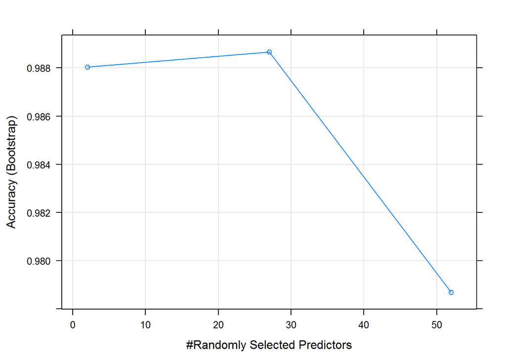

```r
plot(model_randomforest)
```

It looks like we should expect an accuracy somewhere between 98 and 99% when predicting outcomes on out of sample data.

### Model Covariates

We should also try to understand which covariates influenced the model. We’ll use the varImpPlot function to do that.

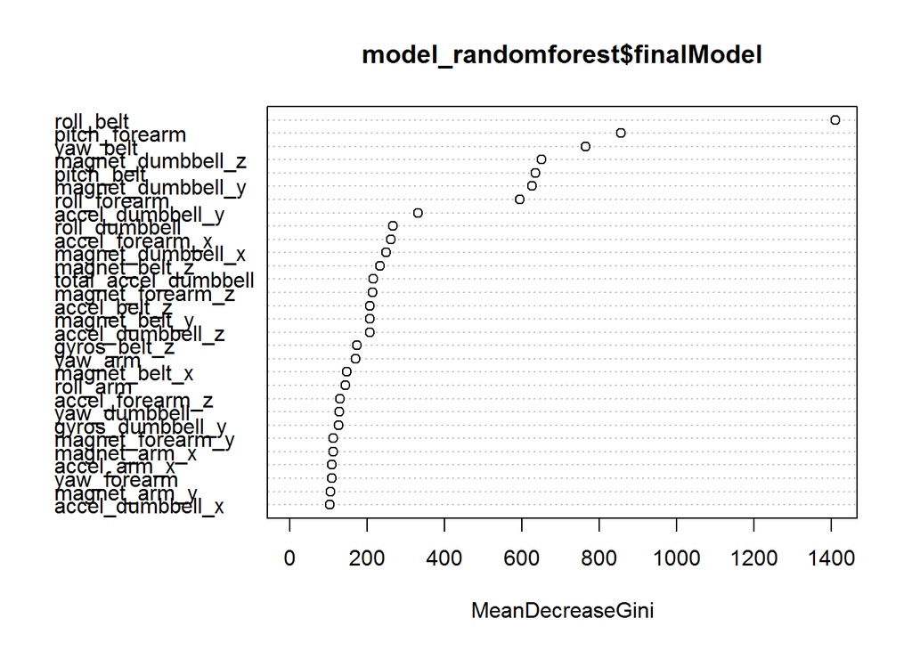

```r
varImpPlot(model_randomforest$finalModel)
```

It looks like 7 covariates dominate the model, with one in particular being esspecially important.

## Cross Validation and Out of Sample Error Rate

Now we’ll apply the model to our test set to see how well it predicts the outcome.

```r
predict_randomforest <- predict(model_randomforest, newdata = testing)
confusionMatrix(predict_randomforest, testing$classe)
```

```
## Confusion Matrix and Statistics
##
##           Reference
## Prediction    A    B    C    D    E
##          A 1672    6    0    0    0
##          B    1 1127    8    0    0
##          C    1    6 1012   11    0
##          D    0    0    6  953    2
##          E    0    0    0    0 1080
##
## Overall Statistics
##
##                Accuracy : 0.993
##                  95% CI : (0.9906, 0.995)
##     No Information Rate : 0.2845
##     P-Value [Acc > NIR] : < 2.2e-16
##
##                   Kappa : 0.9912
##  Mcnemar's Test P-Value : NA
##
## Statistics by Class:
##
##                      Class: A Class: B Class: C Class: D Class: E
## Sensitivity            0.9988   0.9895   0.9864   0.9886   0.9982
## Specificity            0.9986   0.9981   0.9963   0.9984   1.0000
## Pos Pred Value         0.9964   0.9921   0.9825   0.9917   1.0000
## Neg Pred Value         0.9995   0.9975   0.9971   0.9978   0.9996
## Prevalence             0.2845   0.1935   0.1743   0.1638   0.1839
## Detection Rate         0.2841   0.1915   0.1720   0.1619   0.1835
## Detection Prevalence   0.2851   0.1930   0.1750   0.1633   0.1835
## Balanced Accuracy      0.9987   0.9938   0.9913   0.9935   0.9991
```

The results look promising with a 99% accuracy.

## Conclusion

Given the high accuracy of our Random Forest model, we can be reasonable sure that the PCU team predicted the ‘classe’ output using the following covariates at a minimum:

```r
varImp(model_randomforest)
```

```
## rf variable importance
##
##   only 20 most important variables shown (out of 52)
##
##                      Overall
## roll_belt            100.000
## pitch_forearm         60.051
## yaw_belt              53.513
## magnet_dumbbell_z     45.293
## pitch_belt            44.177
## magnet_dumbbell_y     43.581
## roll_forearm          41.318
## accel_dumbbell_y      22.323
## roll_dumbbell         17.644
## accel_forearm_x       17.252
## magnet_dumbbell_x     16.328
## magnet_belt_z         15.200
## total_accel_dumbbell  13.941
## magnet_forearm_z      13.816
## accel_belt_z          13.357
## magnet_belt_y         13.311
## accel_dumbbell_z      13.300
## gyros_belt_z          10.927
## yaw_arm               10.669
## magnet_belt_x          9.081
```

## Prediction Quiz

As a final step, we’ll apply our Random Forest model against the original validation set (pml-testing.csv) to complete the quiz.

```r
predict_quiz <- predict(model_randomforest, newdata = validation)
print(predict_quiz)
```

```
##  [1] B A B A A E D B A A B C B A E E A B B B
## Levels: A B C D E
```